# Natural Language Processing

I’ve selected the webpage consisting of transcripts of CNN Covers the First Republican Presidential Debate of the 2024 Election, which was aired from 11 p.m. to 12 a.m. ET. The URL for my text is “[https://transcripts.cnn.com/show/se/date/2023-08-23/segment/02”](https://transcripts.cnn.com/show/se/date/2023-08-23/segment/02%E2%80%9D). Analyzing a transcript of a significant event, such as the first Republican presidential debate of the 2024 election, provides insights into candidates’ stances, popular topics, public sentiments, and the overall political landscape. This type of analysis is fascinating for various reasons. It helped me understand the political discourse by examining the language used by candidates, moderators, and the audience. I could recognize prevailing political ideologies, rhetorical strategies, and the framing of key issues. Examining how CNN portrays and covers the debate allowed me to shed light on media biases, the framing of issues, and the significance given to different candidates or topics during the event. Analyzing the language used by both moderators and candidates revealed the overall sentiment of the debate, individual sentiments towards specific topics, and the emotional tone conveyed throughout. Dissecting the discussions and debates helped me identify recurring themes such as healthcare, foreign policy, economic plans, and social issues that are critical for voters. Lastly, by analyzing how candidates presented themselves, their debating styles, and how they responded to the questions, I could understand their preparedness and potential appeal to voters.

## Part 1. Text Processing

##### **1.1 Import Libraries**

```python
from urllib.request import urlopen
from bs4 import BeautifulSoup
import nltk
import pandas as pd
import re

from nltk.tokenize import sent_tokenize, word_tokenize
# from nltk.corpus import stopwords
# mystopwords = set(stopwords.words("english"))#only include 179 stopwords
import spacy
nlp = spacy.load("en_core_web_sm")
mystopwords = nlp.Defaults.stop_words #inlcude 326 stopwords # much more efficient
from nltk.stem.porter import PorterStemmer
stemmer = PorterStemmer()
from string import punctuation
from spellchecker import SpellChecker
# remember this is the package pyspellchecker
import textacy
import textacy.preprocessing as tprep

from snorkel.preprocess import preprocessor
from snorkel.types import DataPoint
from snorkel.labeling import labeling_function
from snorkel.labeling import PandasLFApplier
import itertools
from itertools import chain
from collections import Counter
from itertools import combinations

import networkx as nx
from matplotlib import pyplot as plt
def normalize(text):
text = tprep.normalize.hyphenated_words(text)
text = tprep.normalize.quotation_marks(text)
text = tprep.normalize.unicode(text)
text = tprep.remove.accents(text)
text = tprep.replace.phone_numbers(text)
text = tprep.replace.urls(text)
text = tprep.replace.emails(text)
text = tprep.replace.user_handles(text)
text = tprep.replace.emojis(text)
return text

re_suspicious = re.compile(r'[&#<>{}\[\]\\]')

def impurity(text, min_len =10):
if text == None or len(text)< min_len:
    return 0
else:
    return len(re_suspicious.findall(text))/len(text)


def clean_up(text, min_len=10):
if pd.notna(text) and len(str(text)) >= min_len:
    # text = html.unescape(str(text))
    text = re.sub(r'<[^<>]*>', ' ', text)
    text = re.sub(r'\[([^\[\]]*)\]\([^\(\)]*\)', r'\1', text)  # [Some text](https://....)
    text = re.sub(r'\[[^\[\]]*\]', ' ', text)  # [0]
    text = re.sub(r'(?:^|\s)[&#<>{}\[\]+|\\:-]{1,}(?:\s|$)', ' ', text)
    text = re.sub(r'(?:^|\s)[\-=\+]{2,}(?:\s|$)', ' ', text)
    text = re.sub(r'\s+', ' ', text)
    text = re.sub(r'\(COMMERCIAL BREAK\)', ' ', text)
    text = re.sub(r'THIS IS A RUSH TRANSCRIPT\. ', ' ', text)
    text = re.sub(r'THIS COPY MAY NOT BE IN ITS FINAL FORM AND MAY BE UPDATED\. ', ' ', text)
    text = re.sub(r'\(APPLAUSE\)', ' ', text)
    text = re.sub(r'\(LAUGHTER\)', ' ', text)
    text = re.sub(r'\(BEGIN VIDEO CLIP\)', ' ', text)
    text = re.sub(r'\(END VIDEO CLIP\)', ' ', text)
    text = re.sub(r'\(BELL RINGING\)', ' ', text)

    return text.strip()
else:
    return ''

def preprocess_text(text):
text = str(text).lower()
text = [str(word) for word in nltk.word_tokenize(str(text)) if word.lower() not in mystopwords and word not in punctuation]
# text = [stemmer.stem(str(word)) for word in text]
text = " ".join(text)
return text

def preprocess(text):
text = str(text).lower()
return [word for word in nltk.word_tokenize(text) if word.lower() and word.isalpha() and word not in mystopwords and word not in punctuation]
```

##### **1.2 Import Text**

```python
myurl = "https://transcripts.cnn.com/show/se/date/2023-08-23/segment/02"
html = urlopen(myurl).read()
soupified = BeautifulSoup(html,"html.parser")
only_story= soupified.find("div", {"class": "cnnBoxContent"}) #Use Inspection option on the website and find the content I want to extract in the html structure
text = only_story.get_text().strip()
text = text[125:] #remove the first few lines that are unnecessary for my analysis
```

##### ** 1.3 Fix Errors and Process Text**

- Utilized web scraping techniques to extract textual data from CNN transcripts website, leveraging BeautifulSoup for HTML parsing.
- Implemented a clean_up function to eliminate extraneous characters andinformationa enclosed in square brackets, denoting timestamps or annotations within the transcript.
- Employed tokenization to segment the extracted text into individual sentences, organizing them into distinct rows within a structured DataFram
- Executed the preprocess_text function to standardize the text data by converting it to lowercase, removing punctuation, and eliminating stopwords. This transformation resulted in the creation of a new column named "clean," housing the processed text for further analysis.

```python
df=pd.DataFrame(sent_tokenize(text), columns = ["text"]) #sentence tokenize the whole text and put each sentence in each row of the dataframe
df['score'] = df['text'].apply(impurity)# check the impurity of the clean column if there's any unwanted character remaineda
df.sort_values(by = ['score'], ascending = False)
```

|  | text | score |
| --- | --- | --- |
| 492 | [23:40:00] But they didn't. | 0.074074 |
| 71 | [23:05:00] But she came out. | 0.071429 |
| 283 | [23:20:01] (LAUGHTER) Because that stuff sells. | 0.042553 |
| 343 | [23:25:03] He's a little bit of a bomb thrower... | 0.031250 |
| 568 | But let's just say you're in the Oval Office -... | 0.027027 |
| ... | ... | ... |
| 238 | The reason people were going after him -- I me... | 0.000000 |
| 239 | Former vice president of the United States goi... | 0.000000 |
| 240 | He's moving up in polls in Iowa. | 0.000000 |
| 241 | He's moving up in polls in New Hampshire. | 0.000000 |
| 704 | (COMMERCIAL BREAK) | 0.000000 |

705 rows × 2 columns

```python
df['clean']= df['text'].apply(clean_up) #apply clean_up function to remove unwanted characters and unwanted phrases in the transcript like COMMERCIAL BREAK, BELL RINGING, APPLAUSE...
df['score2'] = df['clean'].apply(impurity)# check the impurity of the clean column if there's any unwanted character remaineda
df.sort_values(by = ['score2'], ascending = False)
df
```

|  | text | score | clean | score2 |
| --- | --- | --- | --- | --- |
| 0 | Republican Presidential Debate of the 2024 El... | 0.000000 | Republican Presidential Debate of the 2024 Ele... | 0.0 |
| 1 | Aired 11p-12a ET\nAired August 23, 2023 - 23:0... | 0.000000 | Aired 11p-12a ET Aired August 23, 2023 23:00 E... | 0.0 |
| 2 | THIS COPY MAY NOT BE IN ITS FINAL FORM AND MAY... | 0.000000 | THIS COPY MAY NOT BE IN ITS FINAL FORM AND MAY... | 0.0 |
| 3 | (COMMERCIAL BREAK) [23:00:29] ABBY PHILLIP, CN... | 0.016949 | ABBY PHILLIP, CNN HOST: The first republican p... | 0.0 |
| 4 | Anderson Cooper and Dana Bash pick it up right... | 0.000000 | Anderson Cooper and Dana Bash pick it up right... | 0.0 |
| ... | ... | ... | ... | ... |
| 700 | And that nursing home visitation restriction d... | 0.000000 | And that nursing home visitation restriction d... | 0.0 |
| 701 | So, the governor is free to argue, Anderson, t... | 0.000000 | So, the governor is free to argue, Anderson, t... | 0.0 |
| 702 | COOPER: All right. | 0.000000 | COOPER: All right. | 0.0 |
| 703 | Daniel Dale, we'll have more of our debate cov... | 0.000000 | Daniel Dale, we'll have more of our debate cov... | 0.0 |
| 704 | (COMMERCIAL BREAK) | 0.000000 |  | 0.0 |

705 rows × 4 columns

```python
df['clean2']= df['clean'].apply(preprocess_text) #apply preprocess_text function to lower the case, remove the stopwords, punctuations, and return a string with all of the words are joined together again in each row in clean column
df
# It depends on the purpose of the NLP task, I can use either df['clean'] (still have stopwords and punctuations) or df['clean2'] (in lower case, without stopwords and punctuations)
```

|  | text | score | clean | score2 | clean2 |
| --- | --- | --- | --- | --- | --- |
| 0 | Republican Presidential Debate of the 2024 El... | 0.000000 | Republican Presidential Debate of the 2024 Ele... | 0.0 | republican presidential debate 2024 election |
| 1 | Aired 11p-12a ET\nAired August 23, 2023 - 23:0... | 0.000000 | Aired 11p-12a ET Aired August 23, 2023 23:00 E... | 0.0 | aired 11p-12a et aired august 23 2023 23:00 et... |
| 2 | THIS COPY MAY NOT BE IN ITS FINAL FORM AND MAY... | 0.000000 | THIS COPY MAY NOT BE IN ITS FINAL FORM AND MAY... | 0.0 | copy final form updated |
| 3 | (COMMERCIAL BREAK) [23:00:29] ABBY PHILLIP, CN... | 0.016949 | ABBY PHILLIP, CNN HOST: The first republican p... | 0.0 | abby phillip cnn host republican primary debat... |
| 4 | Anderson Cooper and Dana Bash pick it up right... | 0.000000 | Anderson Cooper and Dana Bash pick it up right... | 0.0 | anderson cooper dana bash pick right special p... |
| ... | ... | ... | ... | ... | ... |
| 700 | And that nursing home visitation restriction d... | 0.000000 | And that nursing home visitation restriction d... | 0.0 | nursing home visitation restriction away septe... |
| 701 | So, the governor is free to argue, Anderson, t... | 0.000000 | So, the governor is free to argue, Anderson, t... | 0.0 | governor free argue anderson allowed freedom l... |
| 702 | COOPER: All right. | 0.000000 | COOPER: All right. | 0.0 | cooper right |
| 703 | Daniel Dale, we'll have more of our debate cov... | 0.000000 | Daniel Dale, we'll have more of our debate cov... | 0.0 | daniel dale debate coverage ahead including im... |
| 704 | (COMMERCIAL BREAK) | 0.000000 |  | 0.0 |  |

705 rows × 5 columns

In the processing text section, the problems I encountered were the squared brackets, which indicate the time (e.g., [23:40:00]). This information doesn’t bring any benefit to my analysis, so I used regex to remove all of the unwanted characters and returned the clean text into the new column called ‘clean’. Then I dropped lines containing certain patterns, such as ‘(COMMERCIAL BREAK)’ and other broadcast related tags. That was important to fix because it may affect the result of the calculation of the most common part of POS tagging. I then joined the sentences in the “clean” column, found the specific and universal tag of each word, and put them all in a new DataFrame called DF_tags, making it a better way to implement. I could use techniques such as tokenization to break the text into individual words, stemming to reduce words to their base, or lemmatization to reduce words to their dictionary form as choices to normalize, depending on the goal of my NLP analysis. By examining the most common entities in the text, I could get a general sense of the theme of the text. Verbs signify actions or states of being and could help identify the narrative style of the text. I could note that the text is a “transcript” covering the “CNN Live Event” regarding the “Presidential Debate Election.” I were surprised to note that, upon using spell check and examining the dictionary, it’s not always necessary to replace the words with the corrected ones.

##### ** 1.4 Another method for processting text and Spell Checking (Optional)**

Instead of processing text manually with preprocess_text function, I used textacy to remove stopwords and punctuation

```python
# creating a place to save the data
output = []

# only the tagger and lemmatizer
# nlp is the spacy english language model
for doc in nlp.pipe(df['text'].to_list(), disable=["tok2vec", "ner", "parser"]):
tokens = textacy.extract.words(doc,
        filter_stops = True,           # default True, no stopwords #sometimes stopwords and punctuation kept in information extraction task
        filter_punct = True,           # default True, no punctuation
        filter_nums = True,            # default False, no numbers
        include_pos = None,            # default None = include all
        exclude_pos = None,            # default None = exclude none
        min_freq = 1)                  # minimum frequency of words
output.append([str(word) for word in tokens]) # close output append #
# type(output[0][0]) #the original type is spacy.tokens.token.Token. So when appending into the output list, change the data type of word into string with str() function

output[0:1]
# Counter(chain.from_iterable(output))# Count the frequency of words appeared #from_iterable is used to flatten the list of list out.
```

```
[['Republican', 'Presidential', 'Debate', 'Election']]
```

```python
#Spell checking
token_set =set(chain.from_iterable(output)) #change this list into set consisting of unique words
token_set

spell = SpellChecker()
mispelled_dict={}
mispelled = spell.unknown(token_set)
for word in mispelled:
mispelled_dict[word] = spell.correction(word)
mispelled_dict
```

```
{'hutchinson': None,
'trutherism': None,
'23:25:03': None,
'w.': 'we',
'biden': 'widen',
'relegating': 'delegating',
'23:34:56': None,
'afterhours': None,
'candidacies': 'candidates',
'regularities': 'irregularities',
'11p-12a': None,
'vivek': 'vive',
'prigozhin': None,
'23:40:00': None,
'relitigate': 'litigate',
'u.n.': 'un',
'gdp': 'gap',
'hmm': 'him',
'farah': 'sarah',
'ramaswamy': None,
'pre-': 'prep',
'23:52:08': None,
'mr.': 'mri',
'23:45:00': None,
'souring': 'pouring',
'kaitlan': 'haitian',
'23:55:02': None,
'conflating': 'conflicting',
'moderators': 'moderator',
'zelenskyy': None,
'axelrod': None,
'weaponization': None,
'crosstalk': 'crosswalk',
'23:20:01': None,
'defund': 'defend',
'fl': 'fly',
'reaganesque': None,
'23:00:29': None,
'rubio': 'rubin',
'covid': 'couid',
```

[output cut: 14 more lines]

```
'u.s.': 'us',
'hampshire': None,
'dometimes': 'sometimes',
'kaine': 'kane',
'burgum': 'burger',
'baltics': 'baltic',
'unprompted': 'prompted',
'r': 'i',
'23:05:00': None,
'23:10:01': None,
'desantis': None,
'covid-19': None,
'moines': 'mines',
'gop': 'got',
'v.p.': 'vip'}
```

## Part 2: Information Extraction

##### ** 2.1 Part of Speech Tagging**

- Merged the sentences in the "clean" column into a single string.
- Employed SpaCy's part-of-speech (POS) tagger to annotate the text data with POS tags.
- Converted the annotated data into a Pandas DataFram
- Utilized the DataFrame to compute the most common parts of speech.

```python
spacy_pos_tagged = []
all_text = " ".join(df['clean'].to_list())

spacy_pos_tagged = [(str(word), str(word.tag_), str(word.pos_)) for word in nlp(all_text)]

# spacy_pos_tagged
DF_tags = pd.DataFrame(spacy_pos_tagged, columns=['word', 'specific', 'universal'])
DF_tags.head()
```

|  | word | specific | universal |
| --- | --- | --- | --- |
| 0 | Republican | JJ | ADJ |
| 1 | Presidential | NNP | PROPN |
| 2 | Debate | NNP | PROPN |
| 3 | of | IN | ADP |
| 4 | the | DT | DET |

```python
DF_tags['universal'].value_counts()
```

```
universal
PUNCT    1645
NOUN     1598
PRON     1576
VERB     1346
ADP      1058
DET       864
AUX       836
PROPN     803
ADJ       611
ADV       591
PART      354
CCONJ     341
SCONJ     266
NUM        95
INTJ       64
SPACE       9
Name: count, dtype: int64
```

```python
pd.crosstab(DF_tags['word'], DF_tags['universal']) # crosstab 2 tables at one, this is terminology from spss.
```

| universal word | ADJ | ADP | ADV | AUX | CCONJ | DET | INTJ | NOUN | NUM | PART | PRON | PROPN | PUNCT | SCONJ | SPACE | VERB |
| --- | --- | --- | --- | --- | --- | --- | --- | --- | --- | --- | --- | --- | --- | --- | --- | --- |
|  | 0 | 0 | 0 | 0 | 0 | 0 | 0 | 0 | 0 | 0 | 0 | 0 | 0 | 0 | 6 | 0 |
|  | 0 | 0 | 0 | 0 | 0 | 0 | 0 | 0 | 0 | 0 | 0 | 0 | 0 | 0 | 3 | 0 |
| ! | 0 | 0 | 0 | 0 | 0 | 0 | 0 | 0 | 0 | 0 | 0 | 0 | 2 | 0 | 0 | 0 |
| " | 0 | 0 | 0 | 0 | 0 | 0 | 0 | 0 | 0 | 0 | 0 | 0 | 4 | 0 | 0 | 0 |
| % | 0 | 0 | 0 | 0 | 0 | 0 | 0 | 5 | 0 | 0 | 0 | 0 | 0 | 0 | 0 | 0 |
| ... | ... | ... | ... | ... | ... | ... | ... | ... | ... | ... | ... | ... | ... | ... | ... | ... |
| you | 0 | 0 | 0 | 0 | 0 | 0 | 0 | 0 | 0 | 0 | 177 | 0 | 0 | 0 | 0 | 0 |
| youngest | 1 | 0 | 0 | 0 | 0 | 0 | 0 | 0 | 0 | 0 | 0 | 0 | 0 | 0 | 0 | 0 |
| your | 0 | 0 | 0 | 0 | 0 | 0 | 0 | 0 | 0 | 0 | 15 | 0 | 0 | 0 | 0 | 0 |
| yours | 0 | 0 | 0 | 0 | 0 | 0 | 0 | 2 | 0 | 0 | 0 | 0 | 0 | 0 | 0 | 0 |
| yourself | 0 | 0 | 0 | 0 | 0 | 0 | 0 | 0 | 0 | 0 | 1 | 0 | 0 | 0 | 0 | 0 |

1811 rows × 16 columns

(Note: https://github.com/explosion/spaCy/blob/master/spacy/glossary.py)

##### ** 2.2 Key Phrase Extraction (KPE)**

- Used Textacy to find key phrases in the text

```python
# build an english language for textacy pipe
en = textacy.load_spacy_lang("en_core_web_sm", disable=("parser"))

# build a processor for textacy using spacy and process text
doc = textacy.make_spacy_doc(all_text, lang = en)
doc
# text rank algorithm
[kps for kps, weights in textacy.extract.keyterms.textrank(doc, normalize = "lemma",  topn = 10)]
```

```
['time candidate Vivek Ramaswamy',
'debate stage tonight',
'debate tonight',
'time tonight',
'republican hopeful tonight',
'issue tonight',
'Florida Governor Ron DeSantis',
'good people',
'big winner tonight',
'republican primary debate']
```

```python
terms = set([term for term, weight in textacy.extract.keyterms.textrank(doc)])
print(textacy.extract.utils.aggregate_term_variants(terms))
```

```
[{'time candidate Vivek Ramaswamy'}, {'Florida Governor Ron DeSantis'}, {'republican hopeful tonight'}, {'republican primary debate'}, {'debate stage tonight'}, {'big winner tonight'}, {'debate tonight'}, {'issue tonight'}, {'time tonight'}, {'good people'}]
```

I can note that "debate stage tonight" appears prominently as a key phrase concluding his significance in my text and include mentions of individuals such as "candidate Vivek Ramaswamy," "Florida Governor Ron DeSantis". The keyphrase analysis helps me understand the narrative focus, note key storylines, and recognizing recurring themes or characters.

##### ** 2.3 Name Entity Recognition**

- Used SpaCy to extract named entities

```python
# nlp(all_text).ents
spacy_ner_tagged = [(ent, ent.label_) for ent in nlp(all_text).ents]
DF_NER_tags = pd.DataFrame(spacy_ner_tagged, columns=['word', 'entity'])

# DF_NER_tags
DF_NER_tags['entity'].value_counts()
```

```
entity
PERSON         174
GPE            123
ORG            122
NORP            65
TIME            50
DATE            49
CARDINAL        32
ORDINAL         20
LAW             16
PRODUCT          8
LOC              6
FAC              6
PERCENT          5
WORK_OF_ART      2
EVENT            2
MONEY            1
QUANTITY         1
Name: count, dtype: int64
```

- Applied Snorkel to the data to show any relationship between names.

```python
ent_types = ["PERSON", "GPE"]#,"NORP"]
stored_entities = []

def get_entities(x): ##
  """
  Grabs the names using spacy's entity labeler
  """

processed = nlp(x)

tokens = [word.text for word in processed]

temp = [(ent.text, ent.label_) for ent in processed.ents if ent.label_ in ent_types]

if len(temp) > 1:
temp2 = list(combinations(temp, 2))
for (person1, person2) in temp2:
    person1_words = [word.text for word in nlp(person1[0])]
    person1_ids = [i for i, val in enumerate(tokens) if val in person1_words]
    if len(person1_words) > 1:
    person1_ids2 = tuple(idx for idx in person1_ids[0:2])
    else:
    id_1 = [idx for idx in person1_ids]
    person1_ids2 = (id_1[0], id_1[0])

    person2_words = [word.text for word in nlp(person2[0])]
    person2_ids = [i for i, val in enumerate(tokens) if val in person2_words[0:2]]
    if len(person2_words) > 1:
    person2_ids2 = tuple(idx for idx in person2_ids)
    else:
    id_2 = [idx for idx in person2_ids]
    person2_ids2 = (id_2[0], id_2[0])

    stored_entities.append(
    [x, # original text
    tokens, # tokens
    person1[0], # person 1 name
    person2[0], # person 2 name
    person1_ids2, # person 1 id token tuple
    person2_ids2 # person 2 id token tuple
    ])

    # Adding custom rule for entity recognition
    for idx, token in enumerate(tokens):
    if token.lower() == "cnn" and idx < len(tokens) - 1 and tokens[idx + 1].lower() in ["host", "commentator"]:
        temp.append(("CNN"))
df['clean'].apply(get_entities)


DF_dev = pd.DataFrame(stored_entities, columns = ["sentence", "tokens", "person1", "person2", "person1_word_idx", "person2_word_idx"])
df['clean'].apply(get_entities)


DF_dev = pd.DataFrame(stored_entities, columns = ["sentence", "tokens", "person1", "person2", "person1_word_idx", "person2_word_idx"])
DF_dev
```

|  | sentence | tokens | person1 | person2 | person1_word_idx | person2_word_idx |
| --- | --- | --- | --- | --- | --- | --- |
| 0 | ABBY PHILLIP, CNN HOST: The first republican p... | [ABBY, PHILLIP, ,, CNN, HOST, :, The, first, r... | ABBY PHILLIP | Milwaukee | (0, 1) | (15, 15) |
| 1 | Anderson Cooper and Dana Bash pick it up right... | [Anderson, Cooper, and, Dana, Bash, pick, it, ... | Anderson Cooper | Dana Bash | (0, 1) | (3, 4) |
| 2 | I'm here in New York along with Dana Bash at t... | [I, 'm, here, in, New, York, along, with, Dana... | New York | Dana Bash | (4, 5) | (8, 9) |
| 3 | I'm here in New York along with Dana Bash at t... | [I, 'm, here, in, New, York, along, with, Dana... | New York | Milwaukee | (4, 5) | (15, 15) |
| 4 | I'm here in New York along with Dana Bash at t... | [I, 'm, here, in, New, York, along, with, Dana... | Dana Bash | Milwaukee | (8, 9) | (15, 15) |
| ... | ... | ... | ... | ... | ... | ... |
| 271 | He ordered 14-day isolation or quarantine, a p... | [He, ordered, 14, -, day, isolation, or, quara... | New York | Louisiana | (19, 20) | (28, 28) |
| 272 | He ordered 14-day isolation or quarantine, a p... | [He, ordered, 14, -, day, isolation, or, quara... | Connecticut | New Jersey | (22, 22) | (19, 24, 25) |
| 273 | He ordered 14-day isolation or quarantine, a p... | [He, ordered, 14, -, day, isolation, or, quara... | Connecticut | Louisiana | (22, 22) | (28, 28) |
| 274 | He ordered 14-day isolation or quarantine, a p... | [He, ordered, 14, -, day, isolation, or, quara... | New Jersey | Louisiana | (19, 24) | (28, 28) |
| 275 | Daniel Dale, we'll have more of our debate cov... | [Daniel, Dale, ,, we, 'll, have, more, of, our... | Daniel Dale | Iowa | (0, 1) | (21, 21) |

276 rows × 6 columns

- Grabbed the words in the middle and to the left
- Figured out what the tokens are between the two objects

```python
#words in the middle
@preprocessor()
def get_text_between(cand: DataPoint) -> DataPoint:
    """
    Returns the text between the two person mentions in the sentence
    """
start = cand.person1_word_idx[1] + 1
end = cand.person2_word_idx[0]
cand.between_tokens = " ".join(cand.tokens[start:end])
return cand
```

```python
# words to the left of each entity
@preprocessor()
def get_left_tokens(cand: DataPoint) -> DataPoint:
    """
    Returns tokens in the length 3 window to the left of the person mentions
    """
# TODO: need to pass window as input params
window = 3

end = cand.person1_word_idx[0]
cand.person1_left_tokens = cand.tokens[0:end][-1 - window : -1]

end = cand.person2_word_idx[0]
cand.person2_left_tokens = cand.tokens[0:end][-1 - window : -1]
return cand
```

```python
#Get the dataframe into the right format to use these functions

characters = {"senator", "president", "opponent","governor","leader","Republican","American","Commentator", "communists","Party","Congress",}
places = {","}

pos_character = 1
neg_location = -1
no_relation = 0

@labeling_function(resources=dict(characters=characters), pre=[get_text_between])
def between_characters(x, characters):
return pos_character if len(characters.intersection(set(x.between_tokens.lower()))) > 0 else no_relation

@labeling_function(resources=dict(places=places), pre=[get_text_between])
def between_places(x, places):
return neg_location if len(places.intersection(set(x.between_tokens.lower()))) > 0 else no_relation

@labeling_function(resources=dict(characters=characters), pre=[get_left_tokens])
def left_characters(x, characters):
if len(set(characters).intersection(set(x.person1_left_tokens))) > 0:
    return pos_character
elif len(set(characters).intersection(set(x.person2_left_tokens))) > 0:
    return pos_character
else:
    return no_relation

@labeling_function(resources=dict(places=places), pre=[get_left_tokens])
def left_places(x, places):
if len(set(places).intersection(set(x.person1_left_tokens))) > 0:
    return neg_location
elif len(set(places).intersection(set(x.person2_left_tokens))) > 0:
    return neg_location
else:
    return no_relation
```

```python
# list all your labeling functions
lfs = [
between_characters,
between_places,
left_characters,
left_places
]
# create the apply pipeline
applier = PandasLFApplier(lfs)

# actually apply the thing
L_dev = applier.apply(DF_dev)

L_dev = pd.DataFrame(L_dev, columns=["char1", "place1", "char2", "place2"])

L_dev

DF_combo = pd.concat([DF_dev, L_dev], axis = 1)

DF_combo['character'] = DF_combo['char1'] + DF_combo['char2']
DF_combo['place'] = DF_combo['place1'] + DF_combo['place2']
DF_combo
```

|  | sentence | tokens | person1 | person2 | person1_word_idx | person2_word_idx | char1 | place1 | char2 | place2 | character | place |
| --- | --- | --- | --- | --- | --- | --- | --- | --- | --- | --- | --- | --- |
| 0 | ABBY PHILLIP, CNN HOST: The first republican p... | [ABBY, PHILLIP, ,, CNN, HOST, :, The, first, r... | ABBY PHILLIP | Milwaukee | (0, 1) | (15, 15) | 0 | -1 | 0 | 0 | 0 | -1 |
| 1 | Anderson Cooper and Dana Bash pick it up right... | [Anderson, Cooper, and, Dana, Bash, pick, it, ... | Anderson Cooper | Dana Bash | (0, 1) | (3, 4) | 0 | 0 | 0 | 0 | 0 | 0 |
| 2 | I'm here in New York along with Dana Bash at t... | [I, 'm, here, in, New, York, along, with, Dana... | New York | Dana Bash | (4, 5) | (8, 9) | 0 | 0 | 0 | 0 | 0 | 0 |
| 3 | I'm here in New York along with Dana Bash at t... | [I, 'm, here, in, New, York, along, with, Dana... | New York | Milwaukee | (4, 5) | (15, 15) | 0 | 0 | 0 | 0 | 0 | 0 |
| 4 | I'm here in New York along with Dana Bash at t... | [I, 'm, here, in, New, York, along, with, Dana... | Dana Bash | Milwaukee | (8, 9) | (15, 15) | 0 | 0 | 0 | 0 | 0 | 0 |
| ... | ... | ... | ... | ... | ... | ... | ... | ... | ... | ... | ... | ... |
| 271 | He ordered 14-day isolation or quarantine, a p... | [He, ordered, 14, -, day, isolation, or, quara... | New York | Louisiana | (19, 20) | (28, 28) | 0 | -1 | 0 | 0 | 0 | -1 |
| 272 | He ordered 14-day isolation or quarantine, a p... | [He, ordered, 14, -, day, isolation, or, quara... | Connecticut | New Jersey | (22, 22) | (19, 24, 25) | 0 | 0 | 0 | 0 | 0 | 0 |
| 273 | He ordered 14-day isolation or quarantine, a p... | [He, ordered, 14, -, day, isolation, or, quara... | Connecticut | Louisiana | (22, 22) | (28, 28) | 0 | -1 | 0 | 0 | 0 | -1 |
| 274 | He ordered 14-day isolation or quarantine, a p... | [He, ordered, 14, -, day, isolation, or, quara... | New Jersey | Louisiana | (19, 24) | (28, 28) | 0 | 0 | 0 | 0 | 0 | 0 |
| 275 | Daniel Dale, we'll have more of our debate cov... | [Daniel, Dale, ,, we, 'll, have, more, of, our... | Daniel Dale | Iowa | (0, 1) | (21, 21) | 0 | -1 | 1 | 0 | 1 | -1 |

276 rows × 12 columns

I explored relationships between different entities such as characters (e.g., "Mike Pence", "Tim Scott", "Chris Christie") and locations (e.g., "Milwaukee" , "Indiana", "New York" ). The relationships were categorized into positive character, negative location, and no relation based on the presence of specific keywords between the entities and their positions in the text. These relationships align with the context of my text.

##### ** 2.4 Knowledge Graphs**

**Create a co-occurrence graph of the entities linked together in your text using snorkel**

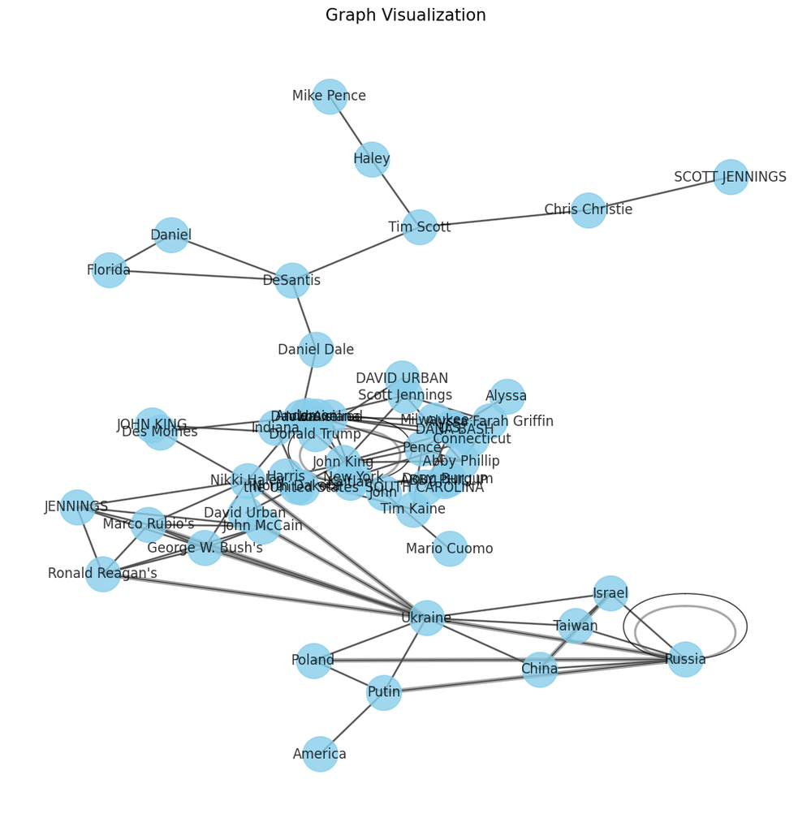

```python
DF_locations = DF_combo[ DF_combo['place'] < 0 ]
DF_locations = DF_locations[["person1", "person2", "character"]]
co_locations = DF_locations.groupby(['person1', 'person2']).agg('count').reset_index().rename(columns = {"character": "weight"})
co_locations = co_locations[~co_locations['person1'].isin(['CNN']) & ~co_locations['person2'].isin(['CNN'])] #dropping CNN as a person
co_locations

graph = nx.from_pandas_edgelist(
        co_locations[['person1', 'person2', 'weight']],
        source='person1', target='person2', edge_attr=True)

pos = nx.kamada_kawai_layout(graph, weight='weight')

_ = plt.figure(figsize=(10, 10))
nx.draw(graph, pos,
    node_size=1000,
    node_color='skyblue',
    alpha=0.8,
    with_labels = True)
plt.title('Graph Visualization', size=15)

for (node1,node2,data) in graph.edges(data=True):
width = data['weight']
_ = nx.draw_networkx_edges(graph,pos,
                            edgelist=[(node1, node2)],
                            width=width,
                            edge_color='#505050',
                            alpha=0.5)

plt.show()
plt.close()
```

```python
# DF_characters = DF_combo[ DF_combo['character'] > 0 ]
# DF_characters = DF_characters[["person1", "person2", "character"]]
# co_character = DF_characters.groupby(['person1', 'person2']).agg('count').reset_index().rename(columns = {"character": "weight"})
# co_character

# DF_characters = DF_characters[["person1", "person2", "character"]]
# co_character = DF_characters.groupby(['person1', 'person2']).agg('count').reset_index().rename(columns = {"character": "weight"})
# co_character

# graph = nx.from_pandas_edgelist(
#            co_character[['person1', 'person2', 'weight']],
#            source='person1', target='person2', edge_attr=True)

# pos = nx.kamada_kawai_layout(graph, weight='weight')

# _ = plt.figure(figsize=(10, 10))
# nx.draw(graph, pos,
#         node_size=1000,
#         node_color='skyblue',
#         alpha=0.8,
#         with_labels = True)
# plt.title('Graph Visualization', size=15)

# for (node1,node2,data) in graph.edges(data=True):
#     width = data['weight']
#     _ = nx.draw_networkx_edges(graph,pos,
#                                edgelist=[(node1, node2)],
#                                width=width,
#                                edge_color='#505050',
#                                alpha=0.5)

# plt.show()
# plt.close()
```

## Part 3: Text Summarization

```python
from nltk.tokenize import BlanklineTokenizer
import pandas as pd
from sentence_transformers import SentenceTransformer

# install faiss-cpu
import faiss
import time

# for summarization
from sumy.parsers.plaintext import PlaintextParser
from sumy.nlp.tokenizers import Tokenizer
from sumy.nlp.stemmers import Stemmer
from sumy.utils import get_stop_words
from sumy.summarizers.lsa import LsaSummarizer
from sumy.summarizers.text_rank import TextRankSummarizer


# to work with topic models
from nltk.tokenize import word_tokenize
from nltk.corpus import stopwords
from gensim.models.doc2vec import Doc2Vec, TaggedDocument

from gensim.models import LdaModel
from gensim.corpora import Dictionary
import nltk

from rouge_score import rouge_scorer
def print_rouge_score(rouge_score):
for k,v in rouge_score.items():
    print (k, 'Precision:', "{:.2f}".format(v.precision), 'Recall:', "{:.2f}".format(v.recall), 'fmeasure:', "{:.2f}".format(v.fmeasure))


# Topic Visualization
import pyLDAvis
import pyLDAvis.gensim_models #don't skip this
import matplotlib.pyplot as plt
```

##### ** 3.1 Build the Search Engine**

```python
# Define search function
def search(query, k = 5):
# looks at the start time
t= time.time()
# puts the search into the same vector numbers that the
# results to show are in (embeds the search in the
# same way as the original text)
query_vector = model.encode([query])
# return the top number of matches
top_k = index.search(query_vector, k)
# also show the time this took time.time() is current,
# t is start time
print('totaltime: {}'.format(time.time()-t))
# return the original text here
return [clean_list[_id] for _id in top_k[1].tolist()[0]]
```

```python
clean_list = df['clean'].to_list()
# creates the embeddings -
model = SentenceTransformer('msmarco-MiniLM-L-12-v3')
model_embedded = model.encode(clean_list)
#model.save("saved_model")

# Create an index using FAISS
# figure out which sentence is the best match
# I get the number back, so this index tells me which original sentence it was

index = faiss.IndexFlatL2(model_embedded.shape[1])
index.add(model_embedded)
faiss.write_index(index, 'index_republican_debate')


# I would do the above to set this up and run only once unless I got new documents
# I would also need sentences/paragraphs loaded for this to work
# THEN to put the model into production, I would only need to load this part

index = faiss.read_index('index_republican_debate')
```

```python
# Check the search function
search("Biden", k = 3)

# search("policy", k = 3)

# search("Trump", k = 3)

# search("Russia", k = 3)

# search("Abortion", k = 3)
```

```
totaltime: 0.11522173881530762
```

```
["And I took that as a swipe at Trump as well, basically saying to Republicans, if we spend our entire time relitigating who did what and who's at fault here, that's what Biden wants us to do.",
'I mean, look, Joe Biden has weakened this country at home and abroad.',
'I mean, look, Joe Biden has weakened this country at home and abroad.']
```

I've a simple search engine using sentence embeddings and FAISS indexing.The model used for embeddings is 'msmarco-MiniLM-L-12-v3', and the search is performed by encoding the query and finding the closest vectors in the indexed data.

##### ** 3.2 Create A Recommendation System**

- Using the same “documents”, create a recommendation system based on your sentences.
- Search for similar words within your recommendation system (i.e., search for themes in your document like “love”/”war”, etc.).

```python
clean_text = clean_up(text)
# Prepare the data for doc2vec, build and save a doc2vec model.

d2v_train = [TaggedDocument(words=word_tokenize(clean_text), tags=[str(index)]) for index, text in enumerate(df['text'])]

# Build and save the Doc2Vec model
model = Doc2Vec(vector_size=50,
            alpha=0.025,
            min_count=10,
            dm=1,
            epochs=100)

model.build_vocab(d2v_train)

model.train(d2v_train,
        total_examples=model.corpus_count,
        epochs=model.epochs)

model.save("d2v.model")

# Use the model to look for similar texts.
model = Doc2Vec.load("d2v.model")
```

```python
#Input text for recommendation
rec_text = "Analyzing the key moments and highlights of the First Republican Presidential Debate in the 2024 Election." #Example


rec_vector = model.infer_vector(word_tokenize(rec_text))

# Find similar texts
similar_texts = model.dv.most_similar([rec_vector])

print(similar_texts)

# Display recommendations
for index, similarity in similar_texts:
print(f"Similarity: {similarity:.2f} - Text: {df['clean'][int(index)]}")
```

```
[('654', 0.7948043346405029), ('130', 0.7945245504379272), ('257', 0.7943572998046875), ('81', 0.7943125367164612), ('221', 0.7936581373214722), ('230', 0.7934128046035767), ('469', 0.7929608225822449), ('64', 0.7928024530410767), ('121', 0.7927155494689941), ('315', 0.7920970916748047)]
Similarity: 0.79 - Text: And after a quick exam, he's like, no, you've got a complete rupture.
Similarity: 0.79 - Text: So, I don't you know, I agree, Nikki Haley, I thought, had an excellent night.
Similarity: 0.79 - Text: I did it while marrying my wife, Apoorva, raising our two sons, following our faith in God.
Similarity: 0.79 - Text: I mean, of course, just being president of the free world.
Similarity: 0.79 - Text: The whole goal in these things is to is to have message-laden moments that can go viral.
Similarity: 0.79 - Text: PHILLIP: I mean, there is at this stage in a lot of these campaigns such a thing as peaking too early.
Similarity: 0.79 - Text: PENCE: Because for the last two and a half years, the president and many of his allies have been out, saying something just didn't sell.
Similarity: 0.79 - Text: I think a lot of the folks did a great disservice to their own candidacies by just, you know, talking too much about things that don't matter.
Similarity: 0.79 - Text: AXELROD: Yeah, I agree with that.
Similarity: 0.79 - Text: I had the courage to make that case and other candidates should as well.
```

I have taken the example of "Analyzing the key moments and highlights of the First Republican Presidential Debate in the 2024 Election." and I am using my Recommendation System to find texts similar to this input within the dataset.The similarity scores I got represent the closeness of each text to the input text. However, the results seem to be indicating that the system might not be capturing the specificity of the debate topic effectively. We could instead improve the set of text for recommendations, by providing a more detailed and specific input text that focuses on key aspects like "Examining the candidates' stances on key issues and standout moments during the First Republican Presidential Debate in the 2024 Election."

##### ** 3.3 Create Text Summaries**

```python
#Take human summary as gold standard
gold_standard = "The first Republican presidential debate for the 2024 election featured notable moments and dynamics among the candidates. Former President Donald Trump chose to skip the debate due to his lead in the polls, while Florida Gov. Ron DeSantis shared the stage with other candidates, including political newcomer Vivek Ramaswamy. Ramaswamy, despite being behind Trump in polls, stood out by delivering memorable lines and criticizing rivals as super PAC puppets. The debate also addressed Trump's legal battles, with most candidates expressing support for him, and Ramaswamy vowing to pardon Trump if given the chance. There was a divide among candidates on abortion rights, with Nikki Haley advocating for sending the issue back to the states, while Mike Pence and Rick Scott endorsed a national abortion ban. DeSantis, despite being the highest-polling contender, took a backseat during the debate, with Ramaswamy dominating the spotlight. The lone woman on stage, Nikki Haley, emphasized women's leadership and clashed with Ramaswamy on issues like sending weapons to Ukraine. The rejection of Trump's false election claims was notable, with candidates praising Mike Pence for upholding the Constitution on January 6, 2021. The debate, marked by moments of intensity and unruliness, saw candidates expressing their views on various issues, from climate change to foreign policy. Overall, the dynamics of the debate provided insights into the positions and strategies of the Republican candidates leading up to the 2024 election."
```

```python
num_summary_sentence = 10
LANGUAGE = "english"
stemmer = Stemmer(LANGUAGE)

parser = PlaintextParser.from_string(clean_text, Tokenizer(LANGUAGE))
```

- LSA Summary

```python
### LSA Summary
summarizer = LsaSummarizer(stemmer)
summarizer.stop_words = get_stop_words(LANGUAGE)

lsa_sents = []

for sentence in summarizer(parser.document, num_summary_sentence):
lsa_sents.append(str(sentence))


lsa_summary = " ".join(lsa_sents)
lsa_summary
```

```
"We're going to be joined by our team of political analysts, commentators, fact checkers, and veterans of the same kind of verbal clashes we saw on the debate stage right here in Milwaukee tonight. DAVID URBAN, CNN POLITICAL COMMENTATOR: Well, you know, I think tonight proves that you don't need Don…
```

```python
### Text Rank
summarizer = TextRankSummarizer(stemmer)
summarizer.stop_words = get_stop_words(LANGUAGE)

tr_sents = []

for sentence in summarizer(parser.document, num_summary_sentence):
tr_sents.append(str(sentence))


tr_summary = " ".join(tr_sents)
tr_summary
```

```
"You know, I don't remember which candidate said, like, American people don't want to hear this, they want to hear people argue, they want to hear policies, they want to hear ideas, this is a chance to put things forward. Pence surprised me, and he shouldn't because I worked for Pence, and he's the …
```

```python
### Topic Model

# Create a dictionary representation of the documents.

# first create sentences
sentences = nltk.sent_tokenize(clean_text)

# preprocess those sentences #use gensim
processed_sentences = [preprocess(sent) for sent in sentences]

# create a list of ids to words (0 is cat, 1 is cheese)
dictionary = Dictionary(processed_sentences)

# create the term by document bag of words
corpus = [dictionary.doc2bow(sent) for sent in processed_sentences]

# Train the topic model
LDAmodel = LdaModel(corpus = corpus,
            id2word = dictionary,
            iterations = 400,
            num_topics = 10,
            random_state = 5494,
            update_every = 1,
            chunksize = 100,
            passes = 10,
            alpha = 'auto',
            per_word_topics = True)#

# get the probability of each sentence's topics
probs = [LDAmodel.get_document_topics(sentence) for sentence in corpus]

save_probs = []
i = 0 # this assumes topic 0 is the one you want
# get only topic zero probabilities for each sentence
for document in probs:
for (topic, prob) in document:
if topic == 0:
    save_probs.append((sentences[i], prob))
i = i + 1

# put that into a data frame
DF = pd.DataFrame(save_probs, columns = ["sentence", "prob"])

# take the top X probability sentences
topic_summary = " ".join(DF.sort_values(by = ["prob"], ascending = False)[0:num_summary_sentence].sentence)

topic_summary
```

```
"ALYSSA FARAH GRIFFIN, CNN CONTRIBUTOR: That was my sense was Nikki Haley was the winner of the night. JENNINGS: Yes, he has moved up incrementally in the polls and there was a lot of crosstalk, but Haley had it down. RAMASWAMY: Nikki, I wish you well in your future career on the boards of Lockheed …
```

- Topic Visualization

```python
vis = pyLDAvis.gensim_models.prepare(LDAmodel, corpus, dictionary, n_jobs = 1)
pyLDAvis.save_html(vis, 'LDA_Visualization_Debate.html') ##saves the file
```

- Rouge-N analyzer.

```python
scorer = rouge_scorer.RougeScorer(['rouge1'], use_stemmer=True)
lsa_scores = scorer.score(gold_standard, lsa_summary)
print_rouge_score(lsa_scores)

tr_scores = scorer.score(gold_standard, tr_summary)
print_rouge_score(tr_scores)

topic_scores = scorer.score(gold_standard, topic_summary)
print_rouge_score(topic_scores)
```

```
rouge1 Precision: 0.24 Recall: 0.40 fmeasure: 0.30
rouge1 Precision: 0.27 Recall: 0.42 fmeasure: 0.33
rouge1 Precision: 0.27 Recall: 0.23 fmeasure: 0.25
```

**Which summary was the best when compared to the human summary?**

- Rouge-N Summarization:

The ROUGE analysis measures how many words the human summary and the result summary from each algorithm shared. So compared to the human summary, Text Rank has highest fmeasure score which is the combination of Precision and Recall score.

- Text Summarization Results:

The human summary covers 7 key points such as Trump's absence, Ramaswamy's standout performance, Trump's legal battles, abortion, Ukraine, Mike Pence, and candidates' views on various issues. TextRank performs well, capturing almost all main points except Trump's absence in the debate. It stands out as the best summarization technique. LSA provides a reasonable summary, covering 4 out of the 7 main points: Trump's absence, Ramaswamy standing out, abortion, and Mike Pence. Topic Model - LDA generates less coherent summaries, providing fragmented information without clear coverage of the main ideas. Therefore, TextRank is the most effective summarization technique, followed by LSA, while Topic Model falls short in providing a comprehensive and coherent summary.

## Part 4: Text Classification

```python
from sklearn.model_selection import train_test_split

from sklearn.feature_extraction.text import CountVectorizer
from sklearn.feature_extraction.text import TfidfVectorizer
import gensim
from gensim.models import Word2Vec

from sklearn.svm import LinearSVC
from sklearn.naive_bayes import MultinomialNB
from sklearn.metrics import classification_report

from lime.lime_text import LimeTextExplainer
# import eli5
from matplotlib import pyplot as plt
from sklearn.pipeline import make_pipeline

from sklearn.calibration import CalibratedClassifierCV

import numpy as np
def document_vectorizer(corpus, model, num_features):
vocabulary = set(model.wv.index_to_key)
def average_word_vectors(words, model, vocabulary, num_features):
    feature_vector = np.zeros((num_features,), dtype="float64")
    nwords = 0.
    for word in words:
        if word in vocabulary:
            nwords = nwords + 1.
            feature_vector = np.add(feature_vector, model.wv[word])
    if nwords:
        feature_vector = np.divide(feature_vector, nwords)
    return feature_vector
features = [average_word_vectors(tokenized_sentence, model, vocabulary, num_features)
                for tokenized_sentence in corpus]
return np.array(features)
```

I decided to preprocess the data in two ways as followed:

- Preprocess 1: preprocessing text using SpaCy for tokenization and textacy for removing stopwords, punctuations and numbers and then lowering text case by using the for loop to travel through each token.
- Preprocess 2: insteaad of applying SpaCy, I manually preprocess the text data by first applying word_tokenize of nltk package and use the for loop to go through each token, lowering the case and removing the stopwords and punctuations. Then I also conduct stemming to only extract the stem words.
- Therefore, for the key terms extraction, I also applied clean_up function and textacy to preprocess the text data. Then, since the second dataset ended up with stem words, we also had to apply stemming for the key terms so that the words are matched with each other and facilitate the labeling process.

```python
#Option Preprocess_1: textacy to preprocess + no stemming

def preprocess_text_1(text):
doc = nlp(text, disable=["tok2vec", "ner", "parser"])
tokens = textacy.extract.words(doc,
        filter_stops = True,           # default True, no stopwords #sometimes stopwords and punctuation kept in information extraction task
        filter_punct = True,           # default True, no punctuation
        filter_nums = True,            # default False, no numbers
        include_pos = None,            # default None = include all
        exclude_pos = None,            # default None = exclude none
        min_freq = 1)                  # minimum frequency of words
text = [str(word).lower() for word in tokens]
text = " ".join(text)
return text


#Option Preprocess_2: manual preprocess + stemming
def preprocess_text_2(text):
text = str(text).lower()
text = [str(word) for word in nltk.word_tokenize(str(text)) if word.lower() not in mystopwords and word not in punctuation]
text = [stemmer.stem(str(word)) for word in text]
text = " ".join(text)
return text
```

##### ** 4.1 Preprocess text in 2 ways**

```python
df_pre1=pd.DataFrame(sent_tokenize(text), columns = ["text"])
df_pre1['clean'] = df_pre1['text'].apply(clean_up).apply(preprocess_text_1)
df_pre1.head()
```

|  | text | clean |
| --- | --- | --- |
| 0 | Republican Presidential Debate of the 2024 El... | republican presidential debate election |
| 1 | Aired 11p-12a ET\nAired August 23, 2023 - 23:0... | aired 11p-12a et aired august 23:00 et rush tr... |
| 2 | THIS COPY MAY NOT BE IN ITS FINAL FORM AND MAY... | copy final form updated |
| 3 | (COMMERCIAL BREAK) [23:00:29] ABBY PHILLIP, CN... | abby phillip cnn host republican primary debat... |
| 4 | Anderson Cooper and Dana Bash pick it up right... | anderson cooper dana bash pick right special p... |

```python
df_pre2=pd.DataFrame(sent_tokenize(text), columns = ["text"])
df_pre2['clean'] = df_pre2['text'].apply(clean_up).apply(preprocess_text_2)
df_pre2.head()
```

|  | text | clean |
| --- | --- | --- |
| 0 | Republican Presidential Debate of the 2024 El... | republican presidenti debat 2024 elect |
| 1 | Aired 11p-12a ET\nAired August 23, 2023 - 23:0... | air 11p-12a et air august 23 2023 23:00 et rus... |
| 2 | THIS COPY MAY NOT BE IN ITS FINAL FORM AND MAY... | copi final form updat |
| 3 | (COMMERCIAL BREAK) [23:00:29] ABBY PHILLIP, CN... | abbi phillip cnn host republican primari debat... |
| 4 | Anderson Cooper and Dana Bash pick it up right... | anderson cooper dana bash pick right special p... |

##### ** 4.2 Label the text for classification**

- Create a “label” column by using regular expressions to look for the ten most popular nouns in your text. This column should be true/false, 0/1, yes/no for includes the word or not.

```python
cleaned_text = clean_up(text) #clean up the original text to find the key words
# print(cleaned_text)

# create lable column with the most popular items

# Build an english language for textacy pipe
en = textacy.load_spacy_lang("en_core_web_sm", disable=("parser"))
# Process the cleaned sentence with spaCy
doc = textacy.make_spacy_doc(cleaned_text, lang=en)
# Apply sgrank and get key terms
key_terms = [kps.lower() for kps, weights in textacy.extract.keyterms.sgrank(doc, topn=10)] #lower case of the key words, so that we can look for the terms in the dataframe later on
print(key_terms)
```

```
['mike pence', 'vivek ramaswamy', 'donald trump', 'debate stage', 'united states', 'nikki haley', 'american people', 'foreign policy', 'tonight', 'republican']
```

```python
#create Key_terms_2 from the original key_terms using stemming to fit with the preprocess 2 dataset which had been through stemming as well
key_terms_2 = [stemmer.stem(str(term)) for term in key_terms]
print(key_terms_2)

def label_sentence(text,key_terms):
# Check if any key term is present in the cleaned sentence
label_keyterm = any(term in text for term in key_terms)
return label_keyterm
```

```
['mike p', 'vivek ramaswami', 'donald trump', 'debate stag', 'united st', 'nikki haley', 'american peopl', 'foreign polici', 'tonight', 'republican']
```

```python
# #Preprocess 1: textacy to preprocess + no stemming
# Apply the function to create the 'label' column
df_pre1['label'] = df_pre1.apply(lambda row: label_sentence(row['clean'], key_terms), axis=1)
df_pre1.head()

# Preprocess 2: manual preprocess + stemming
# Apply the function to create the 'label' column # key_terms_2
df_pre2['label'] = df_pre2.apply(lambda row: label_sentence(row['clean'], key_terms_2), axis=1)
df_pre2.head()
```

|  | text | clean | label |
| --- | --- | --- | --- |
| 0 | Republican Presidential Debate of the 2024 El... | republican presidenti debat 2024 elect | True |
| 1 | Aired 11p-12a ET\nAired August 23, 2023 - 23:0... | air 11p-12a et air august 23 2023 23:00 et rus... | False |
| 2 | THIS COPY MAY NOT BE IN ITS FINAL FORM AND MAY... | copi final form updat | False |
| 3 | (COMMERCIAL BREAK) [23:00:29] ABBY PHILLIP, CN... | abbi phillip cnn host republican primari debat... | True |
| 4 | Anderson Cooper and Dana Bash pick it up right... | anderson cooper dana bash pick right special p... | False |

- Delete the word from your sentence so we do not create a perfect prediction using re.sub.

```python
def delete_key(text):
for term in key_terms:
    text= re.sub(term, "", text)
return text
```

```python
# Preprocess 1 dataset:
df_pre1['clean_2'] = df_pre1['clean'].apply(delete_key)

# Preprocess 2 dataset:
df_pre2['clean_2'] = df_pre2['clean'].apply(delete_key)
```

##### ** 4.3 Balance the dataset**

Examine the balance of the data options. Create a balanced dataset and an imbalanced dataset (likely the default).

```python
df_pre1['label'].value_counts()

df_pre2['label'].value_counts()
```

```
label
False    572
True     133
Name: count, dtype: int64
```

```python
#Preprocess 1
# Create a new temporary df with only 200 rows which is labled False, as the original dataframe shows imbalance between True and False row/sentence.
temp_FalseDF_1 = df_pre1[df_pre1['label']== False].sample(n =200,random_state = 56780)
temp_FalseDF_1['label'].value_counts()
#create balanced data
#concatenate the temporary df above with the original df with only True labeled data to make a balanced_df
df_balanced_pre1 = pd.concat([temp_FalseDF_1, df_pre1[df_pre1['label'] == True]])
df_balanced_pre1['label'].value_counts()
df_balanced_pre1
```

|  | text | clean | label | clean_2 |
| --- | --- | --- | --- | --- |
| 257 | I did it while marrying my wife, Apoorva, rais... | marrying wife apoorva raising sons following f... | False | marrying wife apoorva raising sons following f... |
| 196 | Absolutely. | absolutely | False | absolutely |
| 77 | COOPER: -- a lot of the clips and the exchanges. | cooper lot clips exchanges | False | cooper lot clips exchanges |
| 631 | It shouldn't be something -- even for elected ... | elected officials congress state issue | False | elected officials congress state issue |
| 184 | That is not the winning position with the base... | winning position base party right | False | winning position base party right |
| ... | ... | ... | ... | ... |
| 636 | So, as Republicans, you know, it wasn't that l... | republicans know long ago tea party movement e... | True | s know long ago tea party movement everybody l... |
| 662 | There was no way that I was going to miss bein... | way going miss stage tonight man standing leg ... | True | way going miss stage man standing leg hours |
| 668 | I'm joined by CNN's Daniel Dale, who's got a f... | joined cnn daniel dale got fact check republic... | True | joined cnn daniel dale got fact check voters ... |
| 701 | So, the governor is free to argue, Anderson, t... | governor free argue anderson allowed freedom l... | True | governor free argue anderson allowed freedom l... |
| 703 | Daniel Dale, we'll have more of our debate cov... | daniel dale debate coverage ahead including im... | True | daniel dale debate coverage ahead including im... |

351 rows × 4 columns

```python
#Preprocess 2
# Create a new temporary df with only 200 rows which is labled False, as the original dataframe shows imbalance between True and False row/sentence.
temp_FalseDF_2 = df_pre2[df_pre2['label']== False].sample(n =200,random_state = 56781)
temp_FalseDF_2['label'].value_counts()
#create balanced data
#concatenate the temporary df above with the original df with only True labeled data to make a balanced_df
df_balanced_pre2 = pd.concat([temp_FalseDF_2, df_pre2[df_pre2['label'] == True]])
df_balanced_pre2['label'].value_counts()
df_balanced_pre2
```

|  | text | clean | label | clean_2 |
| --- | --- | --- | --- | --- |
| 551 | RAMASWAMY: You've been pushing this lie. | ramaswami push lie | False | ramaswami push lie |
| 60 | URBAN: I think the moderators -- it's cable. | urban think moder cabl | False | urban think moder cabl |
| 536 | Thank you so much for being here. | thank | False | thank |
| 353 | HUTCHINSON: Thank you. | hutchinson thank | False | hutchinson thank |
| 472 | But my duty under the Constitution was to pres... | duti constitut presid joint session congress v... | False | duti constitut presid joint session congress v... |
| ... | ... | ... | ... | ... |
| 636 | So, as Republicans, you know, it wasn't that l... | republican know long ago tea parti movement ev... | True | know long ago tea parti movement everybodi li... |
| 662 | There was no way that I was going to miss bein... | way go miss stage tonight man stand leg hour | True | way go miss stage man stand leg hour |
| 668 | I'm joined by CNN's Daniel Dale, who's got a f... | join cnn daniel dale got fact check republican... | True | join cnn daniel dale got fact check voter heard |
| 701 | So, the governor is free to argue, Anderson, t... | governor free argu anderson allow freedom lot ... | True | governor free argu anderson allow freedom lot ... |
| 703 | Daniel Dale, we'll have more of our debate cov... | daniel dale debat coverag ahead includ impress... | True | daniel dale debat coverag ahead includ impress... |

333 rows × 4 columns

##### ** 4.4 Train - Test split**

```python
### Split the data


# Imbalanced + preprocess 1 dataset
df_pre1
# Imbalanced + preprocess 2 dataset
df_pre2
# Balanced + preprocess 1 dataset
df_balanced_pre1
# Balanced + preprocess 2 dataset
df_balanced_pre2
```

|  | text | clean | label | clean_2 |
| --- | --- | --- | --- | --- |
| 551 | RAMASWAMY: You've been pushing this lie. | ramaswami push lie | False | ramaswami push lie |
| 60 | URBAN: I think the moderators -- it's cable. | urban think moder cabl | False | urban think moder cabl |
| 536 | Thank you so much for being here. | thank | False | thank |
| 353 | HUTCHINSON: Thank you. | hutchinson thank | False | hutchinson thank |
| 472 | But my duty under the Constitution was to pres... | duti constitut presid joint session congress v... | False | duti constitut presid joint session congress v... |
| ... | ... | ... | ... | ... |
| 636 | So, as Republicans, you know, it wasn't that l... | republican know long ago tea parti movement ev... | True | know long ago tea parti movement everybodi li... |
| 662 | There was no way that I was going to miss bein... | way go miss stage tonight man stand leg hour | True | way go miss stage man stand leg hour |
| 668 | I'm joined by CNN's Daniel Dale, who's got a f... | join cnn daniel dale got fact check republican... | True | join cnn daniel dale got fact check voter heard |
| 701 | So, the governor is free to argue, Anderson, t... | governor free argu anderson allow freedom lot ... | True | governor free argu anderson allow freedom lot ... |
| 703 | Daniel Dale, we'll have more of our debate cov... | daniel dale debat coverag ahead includ impress... | True | daniel dale debat coverag ahead includ impress... |

333 rows × 4 columns

```python
# Imbalanced + preprocess 1 dataset

# on the left hand side of the equals:
# predictor data is X and the classification labels are Y
X_train_im_pre1, X_test_im_pre1, Y_train_im_pre1, Y_test_im_pre1 = train_test_split(df_pre1['clean_2'], # X values
                                                df_pre1['label'], # Y values
                                                test_size = 0.2, # test size
                                                random_state = 67890, # random shuffle
                                                stratify = df_pre1['label'])

print('Size of Training Data ', X_train_im_pre1.shape[0])
print('Size of Test Data ', X_test_im_pre1.shape[0])
```

```
Size of Training Data  564
Size of Test Data  141
```

```python
# Imbalanced + preprocess 2 dataset

# on the left hand side of the equals:
# predictor data is X and the classification labels are Y
X_train_im_pre2, X_test_im_pre2, Y_train_im_pre2, Y_test_im_pre2 = train_test_split(df_pre2['clean_2'], # X values
                                                df_pre2['label'], # Y values
                                                test_size = 0.2, # test size
                                                random_state = 67891, # random shuffle
                                                stratify = df_pre2['label'])

print('Size of Training Data ', X_train_im_pre2.shape[0])
print('Size of Test Data ', X_test_im_pre2.shape[0])
```

```
Size of Training Data  564
Size of Test Data  141
```

```python
# Balanced + preprocess 1 dataset

# on the left hand side of the equals:
# predictor data is X and the classification labels are Y
X_train_b_pre1, X_test_b_pre1, Y_train_b_pre1, Y_test_b_pre1 = train_test_split(df_balanced_pre1['clean_2'], # X values
                                                df_balanced_pre1['label'], # Y values
                                                test_size = 0.2, # test size
                                                random_state = 67892, # random shuffle
                                                stratify = df_balanced_pre1['label'])

print('Size of Training Data ', X_train_b_pre1.shape[0])
print('Size of Test Data ', X_test_b_pre1.shape[0])
```

```
Size of Training Data  280
Size of Test Data  71
```

```python
# Balanced + preprocess 2 dataset

# on the left hand side of the equals:
# predictor data is X and the classification labels are Y
X_train_b_pre2, X_test_b_pre2, Y_train_b_pre2, Y_test_b_pre2 = train_test_split(df_balanced_pre2['clean_2'], # X values
                                                df_balanced_pre2['label'], # Y values
                                                test_size = 0.2, # test size
                                                random_state = 67892, # random shuffle
                                                stratify = df_balanced_pre2['label'])

print('Size of Training Data ', X_train_b_pre2.shape[0])
print('Size of Test Data ', X_test_b_pre2.shape[0])
```

```
Size of Training Data  266
Size of Test Data  67
```

##### ** 4.5 Create Feature Extractions**

Create two different encoding options for your text:

- **TFIDF**

```python
# Imbalanced + preprocess 1 +TFIDF
tf_im_pre1= TfidfVectorizer()

tf_train_im_pre1 = tf_im_pre1.fit_transform(X_train_im_pre1)
tf_test_im_pre1= tf_im_pre1.transform(X_test_im_pre1)
print(tf_train_im_pre1.shape)
print(tf_test_im_pre1.shape)


# Imbalanced + preprocess 2 +TFIDF
tf_im_pre2= TfidfVectorizer()

tf_train_im_pre2 = tf_im_pre2.fit_transform(X_train_im_pre2)
tf_test_im_pre2= tf_im_pre2.transform(X_test_im_pre2)
print(tf_train_im_pre2.shape)
print(tf_test_im_pre2.shape)


# Balanced + preprocess 1 +TFIDF
tf_b_pre1= TfidfVectorizer()

tf_train_b_pre1 = tf_b_pre1.fit_transform(X_train_b_pre1)
tf_test_b_pre1= tf_b_pre1.transform(X_test_b_pre1)
print(tf_train_b_pre1.shape)
print(tf_test_b_pre1.shape)

# Balanced + preprocess 2 +TFIDF
tf_b_pre2= TfidfVectorizer()

tf_train_b_pre2 = tf_b_pre2.fit_transform(X_train_b_pre2)
tf_test_b_pre2= tf_b_pre2.transform(X_test_b_pre2)
print(tf_train_b_pre2.shape)
print(tf_test_b_pre2.shape)
```

```
(564, 1196)
(141, 1196)
(564, 1043)
(141, 1043)
(280, 840)
(71, 840)
(266, 704)
(67, 704)
```

- **Word2vec: CBOW and SkipGram algorithm**

```python
# Imbalanced + preprocess 1 + CBOW
model_im_pre1_cbow = Word2Vec(X_train_im_pre1,
vector_size = 1000 , #dimensions
window = 5, #window size
sg = 0, #cbow
min_count = 1,
workers = 4)

wv_cbow_train_im_pre1 = document_vectorizer(X_train_im_pre1, model_im_pre1_cbow, 1000)
wv_cbow_test_im_pre1 = document_vectorizer(X_test_im_pre1, model_im_pre1_cbow, 1000)
print(wv_cbow_train_im_pre1.shape)
print(wv_cbow_test_im_pre1.shape)

# Imbalanced + preprocess 2 + CBOW
model_im_pre2_cbow = Word2Vec(X_train_im_pre2,
vector_size = 1000, #dimensions
window = 5, #window size
sg = 0, #cbow
min_count = 1,
workers = 4)

wv_cbow_train_im_pre2 = document_vectorizer(X_train_im_pre2, model_im_pre2_cbow, 1000)
wv_cbow_test_im_pre2 = document_vectorizer(X_test_im_pre2, model_im_pre2_cbow, 1000)
print(wv_cbow_train_im_pre2.shape)
print(wv_cbow_test_im_pre2.shape)

# Balanced + preprocess 1 + CBOW
model_b_pre1_cbow = Word2Vec(X_train_b_pre1,
vector_size = 1000, #dimensions
window = 5, #window size
sg = 0, #cbow
min_count = 1,
workers = 4)

wv_cbow_train_b_pre1 = document_vectorizer(X_train_b_pre1, model_b_pre1_cbow, 1000)
wv_cbow_test_b_pre1 = document_vectorizer(X_test_b_pre1, model_b_pre1_cbow, 1000)
print(wv_cbow_train_b_pre1.shape)
print(wv_cbow_test_b_pre1.shape)

# Balanced + preprocess 2 + CBOW
model_b_pre2_cbow = Word2Vec(X_train_b_pre2,
vector_size = 1000, #dimensions
window = 5, #window size
sg = 0, #cbow
min_count = 1,
workers = 4)

wv_cbow_train_b_pre2 = document_vectorizer(X_train_b_pre2, model_b_pre2_cbow, 1000)
wv_cbow_test_b_pre2 = document_vectorizer(X_test_b_pre2, model_b_pre2_cbow, 1000)
print(wv_cbow_train_b_pre2.shape)
print(wv_cbow_test_b_pre2.shape)
```

```
WARNING:gensim.models.word2vec:Each 'sentences' item should be a list of words (usually unicode strings). First item here is instead plain <class 'str'>.
WARNING:gensim.models.word2vec:Each 'sentences' item should be a list of words (usually unicode strings). First item here is instead plain <class 'str'>.
WARNING:gensim.models.word2vec:Each 'sentences' item should be a list of words (usually unicode strings). First item here is instead plain <class 'str'>.
```

```
(564, 1000)
(141, 1000)
(564, 1000)
(141, 1000)
```

```
WARNING:gensim.models.word2vec:Each 'sentences' item should be a list of words (usually unicode strings). First item here is instead plain <class 'str'>.
```

```
(280, 1000)
(71, 1000)
(266, 1000)
(67, 1000)
```

```python
# Imbalanced + preprocess 1 + SG
model_im_pre1_sg = Word2Vec(X_train_im_pre1,
vector_size = 1000, #dimensions
window = 5, #window size
sg = 1, #sg
min_count = 1,
workers = 4)

wv_sg_train_im_pre1 = document_vectorizer(X_train_im_pre1, model_im_pre1_sg, 1000)
wv_sg_test_im_pre1 = document_vectorizer(X_test_im_pre1, model_im_pre1_sg, 1000)
print(wv_sg_train_im_pre1.shape)
print(wv_sg_test_im_pre1.shape)

# Imbalanced + preprocess 2 + SG
model_im_pre2_sg = Word2Vec(X_train_im_pre2,
vector_size = 1000, #dimensions
window = 5, #window size
sg = 1, #sg
min_count = 1,
workers = 4)

wv_sg_train_im_pre2 = document_vectorizer(X_train_im_pre2, model_im_pre2_sg, 1000)
wv_sg_test_im_pre2 = document_vectorizer(X_test_im_pre2, model_im_pre2_sg, 1000)
print(wv_sg_train_im_pre2.shape)
print(wv_sg_test_im_pre2.shape)

# Balanced + preprocess 1 + SG
model_b_pre1_sg = Word2Vec(X_train_b_pre1,
vector_size = 1000, #dimensions
window = 5, #window size
sg = 1, #sg
min_count = 1,
workers = 4)

wv_sg_train_b_pre1 = document_vectorizer(X_train_b_pre1, model_b_pre1_sg, 1000)
wv_sg_test_b_pre1 = document_vectorizer(X_test_b_pre1, model_b_pre1_sg, 1000)
print(wv_sg_train_b_pre1.shape)
print(wv_sg_test_b_pre1.shape)

# Balanced + preprocess 2 + SG
model_b_pre2_sg = Word2Vec(X_train_b_pre2,
vector_size = 1000, #dimensions
window = 5, #window size
sg = 1, # sg
min_count = 1,
workers = 4)

wv_sg_train_b_pre2 = document_vectorizer(X_train_b_pre2, model_b_pre2_sg, 1000)
wv_sg_test_b_pre2 = document_vectorizer(X_test_b_pre2, model_b_pre2_sg, 1000)
print(wv_sg_train_b_pre2.shape)
print(wv_sg_test_b_pre2.shape)
```

```
WARNING:gensim.models.word2vec:Each 'sentences' item should be a list of words (usually unicode strings). First item here is instead plain <class 'str'>.
WARNING:gensim.models.word2vec:Each 'sentences' item should be a list of words (usually unicode strings). First item here is instead plain <class 'str'>.
```

```
(564, 1000)
(141, 1000)
```

```
WARNING:gensim.models.word2vec:Each 'sentences' item should be a list of words (usually unicode strings). First item here is instead plain <class 'str'>.
```

```
(564, 1000)
(141, 1000)
(280, 1000)
(71, 1000)
```

```
WARNING:gensim.models.word2vec:Each 'sentences' item should be a list of words (usually unicode strings). First item here is instead plain <class 'str'>.
```

```
(266, 1000)
(67, 1000)
```

I decided to use TF-IDF and word2vec for feature extractions. The normal trend would be to start with very basic vectorization, like one-hot encoding or bag of words, then implement more complex ones. But I chose to apply TF-IDF here considering one-hot encoding might be more helpful for short texts, and bag of words assumes that all the words are equally important, while TF-IDF applies the normalization procedure that increases the importance of useful words and decreases the importance of overused words. Thus, TF-IDF is represented by weights rather than counts, and ultimately, it'd be more informative. Furthermore, polysemy is one of the big issues in NLP since words can have so many meanings. Understanding the context can help me deal with disambiguity. So the next feature extraction model I selected is to aim at contextual representation. Thus, word2vec can be of great use, and I decided to use both the CBOW and SkipGram algorithms.

##### ** 4.6 Text Classification**

- **Support Vector Machine**

```python
# #Summary of all the available objects
# ### Imbalanced
# X_train_im_pre1, X_test_im_pre1, Y_train_im_pre1, Y_test_im_pre1
# X_train_im_pre2, X_test_im_pre2, Y_train_im_pre2, Y_test_im_pre2


# #TFIDF - imbalanced - pre 1
# tf_train_im_pre1
# tf_test_im_pre1

# #TFIDF - imbalanced - pre 2
# tf_train_im_pre2
# tf_test_im_pre2


# #CBOW - imbalanced - pre 1
# wv_cbow_train_im_pre1
# wv_cbow_test_im_pre1

# #CBOW - imbalanced - pre 2
# wv_cbow_train_im_pre2
# wv_cbow_test_im_pre2

# #SG - imbalanced -  pre 1
# wv_sg_train_im_pre1
# wv_sg_test_im_pre1

# #SG - imbalanced -  pre 2
# wv_sg_train_im_pre2
# wv_sg_test_im_pre2

# ### Balanced
# X_train_b_pre1, X_test_b_pre1, Y_train_b_pre1, Y_test_b_pre1
# X_train_b_pre2, X_test_b_pre2, Y_train_b_pre2, Y_test_b_pre2
# #TFIDF - balanced - pre 1
# tf_train_b_pre1
# tf_test_b_pre1

# #TFIDF - balanced - pre 2
# tf_train_b_pre2
# tf_test_b_pre2

# #CBOW - balanced - pre 1
# wv_cbow_train_b_pre1
# wv_cbow_test_b_pre1

# #CBOW - balanced - pre 2
# wv_cbow_train_b_pre2
# wv_cbow_test_b_pre2

# #SG - balanced -  pre 1
# wv_sg_train_b_pre1
# wv_sg_test_b_pre1

# #SG - balanced -  pre 2
# wv_sg_train_b_pre2
# wv_sg_test_b_pre2
```

```python
## Support Vector Machine

# 1 #SVM - TFIDF - imbalanced - pre 1
svm = LinearSVC()
svm.fit(tf_train_im_pre1, Y_train_im_pre1)
y_svm = svm.predict(tf_test_im_pre1)
print(classification_report(y_true=Y_test_im_pre1, y_pred=y_svm))



# 2 #SVM - TFIDF - imbalanced - pre 2 --> best model
svm = LinearSVC()
svm.fit(tf_train_im_pre2, Y_train_im_pre2)
y_svm = svm.predict(tf_test_im_pre2)
print(classification_report(y_true=Y_test_im_pre2, y_pred=y_svm))


# 3 #SVM - TFIDF - balanced - pre 1
svm = LinearSVC()
svm.fit(tf_train_b_pre1, Y_train_b_pre1)
y_svm = svm.predict(tf_test_b_pre1)
print(classification_report(y_true=Y_test_b_pre1, y_pred=y_svm))


# 4 #SVM - TFIDF - balanced - pre 2
svm = LinearSVC()
svm.fit(tf_train_b_pre2, Y_train_b_pre2)
y_svm = svm.predict(tf_test_b_pre2)
print(classification_report(y_true=Y_test_b_pre2, y_pred=y_svm))

# 5 #SVM - CBOW - imbalanced - pre 1
svm = LinearSVC()
svm.fit(wv_cbow_train_im_pre1, Y_train_im_pre1)
y_svm = svm.predict(wv_cbow_test_im_pre1)
print(classification_report(y_true=Y_test_im_pre1, y_pred=y_svm))


# 6 #SVM - CBOW - imbalanced - pre 2
svm = LinearSVC()
svm.fit(wv_cbow_train_im_pre2, Y_train_im_pre2)
y_svm = svm.predict(wv_cbow_test_im_pre2)
print(classification_report(y_true=Y_test_im_pre2, y_pred=y_svm))


# 7 #SVM - CBOW - balanced - pre 1
svm = LinearSVC()
svm.fit(wv_cbow_train_b_pre1, Y_train_b_pre1)
y_svm = svm.predict(wv_cbow_test_b_pre1)
print(classification_report(y_true=Y_test_b_pre1, y_pred=y_svm))

# 8 #SVM - CBOW - balanced - pre 2
svm = LinearSVC()
svm.fit(wv_cbow_train_b_pre2, Y_train_b_pre2)
y_svm = svm.predict(wv_cbow_test_b_pre2)
print(classification_report(y_true=Y_test_b_pre2, y_pred=y_svm))

# 9 #SVM - SG - imbalanced - pre 1
svm = LinearSVC()
svm.fit(wv_sg_train_im_pre1, Y_train_im_pre1)
y_svm = svm.predict(wv_sg_test_im_pre1)
print(classification_report(y_true=Y_test_im_pre1, y_pred=y_svm))


# 10 #SVM - SG - imbalanced - pre 2
svm = LinearSVC()
svm.fit(wv_sg_train_im_pre2, Y_train_im_pre2)
y_svm = svm.predict(wv_sg_test_im_pre2)
print(classification_report(y_true=Y_test_im_pre2, y_pred=y_svm))


# 11 #SVM - SG - balanced - pre 1
svm = LinearSVC()
svm.fit(wv_cbow_train_b_pre1, Y_train_b_pre1)
y_svm = svm.predict(wv_cbow_test_b_pre1)
print(classification_report(y_true=Y_test_b_pre1, y_pred=y_svm))

# 12 #SVM - SG- balanced - pre 2
svm = LinearSVC()
svm.fit(wv_sg_train_b_pre2, Y_train_b_pre2)
y_svm = svm.predict(wv_sg_test_b_pre2)
print(classification_report(y_true=Y_test_b_pre2, y_pred=y_svm))
```

```
              precision    recall  f1-score   support

    False       0.82      0.95      0.88       111
    True       0.54      0.23      0.33        30

accuracy                           0.79       141
macro avg       0.68      0.59      0.60       141
weighted avg       0.76      0.79      0.76       141

            precision    recall  f1-score   support

    False       0.86      0.95      0.90       114
    True       0.62      0.37      0.47        27

accuracy                           0.84       141
macro avg       0.74      0.66      0.68       141
weighted avg       0.82      0.84      0.82       141

            precision    recall  f1-score   support

    False       0.65      0.75      0.70        40
    True       0.60      0.48      0.54        31

accuracy                           0.63        71
macro avg       0.63      0.62      0.62        71
weighted avg       0.63      0.63      0.63        71

            precision    recall  f1-score   support

    False       0.68      0.85      0.76        40
    True       0.65      0.41      0.50        27

accuracy                           0.67        67
macro avg       0.66      0.63      0.63        67
weighted avg       0.67      0.67      0.65        67
```

```
              precision    recall  f1-score   support

    False       0.79      1.00      0.88       111
    True       0.00      0.00      0.00        30

accuracy                           0.79       141
macro avg       0.39      0.50      0.44       141
weighted avg       0.62      0.79      0.69       141

            precision    recall  f1-score   support

    False       0.81      1.00      0.89       114
    True       0.00      0.00      0.00        27

accuracy                           0.81       141
macro avg       0.40      0.50      0.45       141
weighted avg       0.65      0.81      0.72       141
```

```
              precision    recall  f1-score   support

    False       0.56      1.00      0.72        40
    True       0.00      0.00      0.00        31

accuracy                           0.56        71
macro avg       0.28      0.50      0.36        71
weighted avg       0.32      0.56      0.41        71

            precision    recall  f1-score   support

    False       0.60      1.00      0.75        40
    True       0.00      0.00      0.00        27

accuracy                           0.60        67
macro avg       0.30      0.50      0.37        67
weighted avg       0.36      0.60      0.45        67

            precision    recall  f1-score   support

    False       0.79      1.00      0.88       111
    True       0.00      0.00      0.00        30

accuracy                           0.79       141
macro avg       0.39      0.50      0.44       141
weighted avg       0.62      0.79      0.69       141

            precision    recall  f1-score   support

    False       0.81      1.00      0.89       114
    True       0.00      0.00      0.00        27

accuracy                           0.81       141
macro avg       0.40      0.50      0.45       141
weighted avg       0.65      0.81      0.72       141

            precision    recall  f1-score   support

    False       0.56      1.00      0.72        40
    True       0.00      0.00      0.00        31

accuracy                           0.56        71
macro avg       0.28      0.50      0.36        71
weighted avg       0.32      0.56      0.41        71

            precision    recall  f1-score   support

    False       0.60      1.00      0.75        40
    True       0.00      0.00      0.00        27

accuracy                           0.60        67
macro avg       0.30      0.50      0.37        67
weighted avg       0.36      0.60      0.45        67
```

- **Naive Bayes**

```python
## Naive Bayes

#Fix issues with negative values in wv models for NB algorithm
print(wv_cbow_train_im_pre1.min())
print(wv_cbow_train_im_pre2.min())
print(wv_cbow_test_im_pre1.min())
print(wv_cbow_test_im_pre2.min())

print(wv_cbow_train_b_pre1.min())
print(wv_cbow_train_b_pre2.min())
print(wv_cbow_test_b_pre1.min())
print(wv_cbow_test_b_pre2.min())

print(wv_sg_train_im_pre1.min())
print(wv_sg_train_im_pre2.min())
print(wv_sg_test_im_pre1.min())
print(wv_sg_test_im_pre2.min())

print(wv_sg_train_b_pre1.min())
print(wv_sg_train_b_pre2.min())
print(wv_sg_test_b_pre1.min())
print(wv_sg_test_b_pre2.min())


wv_cbow_train_im_pre1 = wv_cbow_train_im_pre1+ 1
wv_cbow_train_im_pre2 = wv_cbow_train_im_pre2 + 1

wv_cbow_test_im_pre1 = wv_cbow_test_im_pre1 + 1
wv_cbow_test_im_pre2 = wv_cbow_test_im_pre2 + 1

wv_cbow_train_b_pre1 = wv_cbow_train_b_pre1+ 1
wv_cbow_train_b_pre2 = wv_cbow_train_b_pre2 + 1

wv_cbow_test_b_pre1 = wv_cbow_test_b_pre1 + 1
wv_cbow_test_b_pre2 = wv_cbow_test_b_pre2 + 1

wv_sg_train_im_pre1 = wv_sg_train_im_pre1+ 1
wv_sg_train_im_pre2 = wv_sg_train_im_pre2 + 1

wv_sg_test_im_pre1 = wv_sg_test_im_pre1 + 1
wv_sg_test_im_pre2 = wv_sg_test_im_pre2 + 1

wv_sgtrain_b_pre1 = wv_sg_train_b_pre1+ 1
wv_sg_train_b_pre2 = wv_sg_train_b_pre2 + 1

wv_sg_test_b_pre1 = wv_sg_test_b_pre1 + 1
wv_sg_test_b_pre2 = wv_sg_test_b_pre2 + 1
```

```
-0.15642729848623277
-0.17605453177734656
-0.15537256995836893
-0.16017541446183858
-0.15872810408473015
-0.17114496957965014
-0.15756825730204582
-0.16714533737727574
-0.10935925506055355
-0.10661809284377981
-0.10802550459730215
-0.10529590385002002
-0.10822287760674953
-0.10766639297121558
-0.10744968703702877
-0.10491757236775898
```